# Week 4: Integrating Sleep, Activity, and Glucose

Author

Eric Xie

## 1 Load Packages

```r
library(tidyverse)
library(here)
library(knitr)
library(kableExtra)
library(janitor)
library(jsonlite)
```

## 2 Reviewing Week 2 Solution Keys for Participant-Day CGM Table

### 2.1 Analysis Parameters

```r
expected_readings_per_day <- 288
min_readings_valid_day <- 202
glucose_lower_bound <- 40
glucose_upper_bound <- 400
daytime_start_hour <- 6
```

### 2.2 Dataset Path

```r
# dataset path
dataset_version <- "v3-mini"

data_dir <- here("data/mini")
```

### 2.3 Read Participants Manifest Data

```r
participants <- read_tsv(
  file.path(
    data_dir,
    "participants_mini.tsv"
  ),
  show_col_types = FALSE
) |>
  clean_names()
```

- clean_names() is a janitor function that standardizes column names into a consistent, lowercase, snake_case format

### 2.4 Cohort Files

```r
# cohort files
dexcom_dir <- file.path(
  data_dir,
  "dexcom_g6"
)

# define a vector for the cgm cohort
cgm_cohort <- participants |>
  filter(wearable_blood_glucose) |>
  pull(person_id)

participant_dirs <- list.dirs(dexcom_dir, recursive = FALSE, full.names = TRUE)

cohort_files <- tibble(dir_path = participant_dirs) |>
  mutate(
    folder_name = basename(dir_path),
    person_id = suppressWarnings(as.numeric(str_remove(folder_name, "AIREADI-"))),
    json_path = map_chr(dir_path, function(one_dir) {
      found <- list.files(one_dir, pattern = "\\.json$", full.names = TRUE)
      if (length(found) >= 1) found[1] else NA_character_
    })
  ) |>
  filter(person_id %in% cgm_cohort, !is.na(json_path))
```

- cgm_cohort filtered for participants with wearable_blood_glucose as true, and turned the data frame into a vector with person ids
- cohort_files added folder name, person id, and json paths to the table with dir_path and ensured consistent formatting

### 2.5 Timezone Tables

```r
participant_sites <- participants |>
  select(person_id, clinical_site)

tz_map <- tribble(
  ~timezone_label_json, ~iana_zone,           ~expected_region,
  "pst",                "America/Los_Angeles", "Pacific",
  "pdt",                "America/Los_Angeles", "Pacific",
  "mst",                "America/Denver",      "Mountain",
  "mdt",                "America/Denver",      "Mountain",
  "cst",                "America/Chicago",     "Central",
  "cdt",                "America/Chicago",     "Central",
  "est",                "America/New_York",    "Eastern",
  "edt",                "America/New_York",    "Eastern"
)

site_region_map <- tribble(
  ~clinical_site, ~site_region,
  "UW",           "Pacific",
  "UCSD",         "Pacific",
  "UAB",          "Central"
)
```

### 2.6 Function for clean_one_cgm

```r
clean_one_cgm <- function(json_path) {

  # flattening into tables is quicker than iterating through nested objects
  raw <- fromJSON(
    json_path,
    flatten = TRUE
  )

  person_id_header <- raw$header$patient_id

  pid <- as.numeric(
    str_remove(person_id_header, "AIREADI-")
  )

  tz_label <- str_to_lower(raw$header$timezone)

  cgm_raw <- as_tibble(raw$body$cgm)

  # Step 1: keep estimated glucose value events only.
  # Step 2: timestamps end in "Z", so they are parsed as UTC.
  #
  # as.character() is applied to the glucose value before as.numeric()
  # because Dexcom writes "Low" and "High" as sentinel strings. This makes
  # the column character in some files and integer in others, and the two
  # types cannot be combined across participants without an explicit cast.

  egv <- cgm_raw |>
    filter(event_type == "EGV") |>
    transmute(
      person_id = pid,
      event_type,
      timezone_label_json = tz_label,
      time_utc = ymd_hms(
        effective_time_frame.time_interval.start_date_time,
        tz = "UTC",
        quiet = TRUE
      ),
      glucose_value_original = as.character(blood_glucose.value),
      glucose_value_numeric = suppressWarnings(
        as.numeric(glucose_value_original)
      ),
      glucose_unit = blood_glucose.unit
    ) # each row represents one glucose reading

  n_raw_egv <- nrow(egv) # counts how many rows are in egv data frame

  # Step 3: infer the regional timezone from the JSON label and check it
  # against the clinical site.
  #
  # The JSON header says "pst" and the clinical site is UW.
  # We interpret this as US Pacific Time and use "America/Los_Angeles"
  # for its timezone and daylight-saving rules. R determines whether
  # each individual timestamp is PST or PDT.
  #
  # A label that cannot be mapped at all means we cannot localize the
  # readings, so the participant is flagged and returns no clean readings.
  # A label that maps successfully but disagrees with the clinical site is
  # also flagged for human review, rather than being silently overridden.

  tz_match <- tz_map |>
    filter(timezone_label_json == tz_label)

  site_value <- participant_sites |>
    filter(person_id == pid) |>
    pull(clinical_site)

  site_match <- site_region_map |>
    filter(clinical_site %in% site_value)

  iana_zone <- if (nrow(tz_match) == 1) {
    tz_match$iana_zone
  } else {
    NA_character_
  }

  expected_region <- if (nrow(tz_match) == 1) {
    tz_match$expected_region
  } else {
    NA_character_
  }

  site_region <- if (nrow(site_match) == 1) {
    site_match$site_region
  } else {
    NA_character_
  }

  tz_site_consistent <- !is.na(expected_region) &
    !is.na(site_region) &
    expected_region == site_region

  tz_qc <- tibble(
    person_id = pid,
    timezone_label_json = tz_label,
    iana_zone = iana_zone,
    clinical_site = if (length(site_value) == 1) {
      site_value
    } else {
      NA_character_
    },
    expected_region = expected_region,
    site_region = site_region,
    tz_site_consistent = tz_site_consistent,
    tz_flag_for_review = is.na(iana_zone) | !tz_site_consistent
  )

  # placeholder list in case of errors
  empty_result <- list(
    reading_level = tibble(),
    day_counts = tibble(),
    dst_notes = tibble(),
    tz_qc = tz_qc,
    qc_summary = tibble(
      person_id = pid,
      raw_egv_readings = n_raw_egv,
      missing_timestamps = sum(is.na(egv$time_utc)),
      missing_glucose = sum(is.na(egv$glucose_value_numeric)),
      duplicate_timestamps = NA_integer_,
      conflicting_duplicates = NA_integer_,
      nonstandard_units = NA_integer_,
      unusual_values = NA_integer_,
      cleaned_readings = 0L,
      valid_days = 0L,
      excluded_duplicate_readings = NA_integer_,
      excluded_missing_glucose = NA_integer_,
      excluded_units = NA_integer_,
      excluded_unusual = NA_integer_
    )
  )

  if (is.na(iana_zone) || n_raw_egv == 0) {
    return(empty_result)
  }

  # Step 4: convert to local time and derive the local calendar variables.
  # timezone_abbreviation is taken per reading rather than from the header,
  # so a participant recorded across a transition shows both PDT and PST.

  egv <- egv |>
    mutate(
      time_local = with_tz(time_utc, tzone = iana_zone),
      date_local = as_date(time_local),
      hour_local = hour(time_local),
      timezone_abbreviation = format(time_local, "%Z"),
      is_dst = dst(time_local)
    )

  # Step 6: count missing timestamps and missing glucose values.
  # "Low" and "High" become NA on conversion and are counted here.

  n_missing_timestamps <- sum(is.na(egv$time_utc))

  n_missing_glucose <- sum(is.na(egv$glucose_value_numeric))

  # Step 7: a duplicate is the same participant ID and UTC timestamp.
  # Duplicates that agree on glucose collapse to a single copy.
  # Duplicates that disagree are flagged and excluded entirely, because
  # there is no basis for choosing between the conflicting values.
  #
  # This rule is from Shubho's work. It is
  # adopted here in preference to keeping the first copy, because the
  # cohort does contain conflicting duplicates.

  duplicate_groups <- egv |>
    filter(!is.na(time_utc)) |>
    group_by(person_id, time_utc) |>
    summarise(
      number_of_rows = n(),
      number_of_distinct_values = n_distinct(glucose_value_numeric),
      .groups = "drop"
    ) |>
    filter(number_of_rows > 1)

  conflicting_keys <- duplicate_groups |>
    filter(number_of_distinct_values > 1) |>
    select(person_id, time_utc)

  n_duplicate_timestamps <- nrow(duplicate_groups)

  n_conflicting_duplicates <- nrow(conflicting_keys)

  egv_timed <- egv |>
    filter(!is.na(time_utc))

  egv_dedup <- egv_timed |>
    anti_join(
      conflicting_keys,
      by = c("person_id", "time_utc")
    ) |>
    distinct(person_id, time_utc, .keep_all = TRUE)

  # Duplicate handling removes whole rows, and one conflicting group of two
  # rows removes two readings. This row count, not the group count, is what
  # the cohort funnel below needs in order to reconcile exactly.

  n_duplicate_readings_removed <- nrow(egv_timed) - nrow(egv_dedup)

  # Step 8: confirm that glucose is recorded in mg/dL. Any other unit is
  # flagged and excluded, because the 40-400 range check below and every
  # summary in this notebook assume mg/dL.

  egv_dedup <- egv_dedup |>
    mutate(
      unit_flag = is.na(glucose_unit) | glucose_unit != "mg/dL"
    )

  # Step 9: flag values below 40 or above 400 mg/dL as unusual and exclude
  # them. This is a data-processing rule, not a clinical definition.

  egv_dedup <- egv_dedup |>
    mutate(
      unusual_value_flag = !is.na(glucose_value_numeric) &
        (glucose_value_numeric < glucose_lower_bound |
           glucose_value_numeric > glucose_upper_bound)
    )

  n_nonstandard_units <- sum(egv_dedup$unit_flag)

  n_unusual <- sum(egv_dedup$unusual_value_flag)

  # The three exclusion rules above can apply to the same reading, so the
  # cohort funnel needs counts that charge each excluded reading to exactly
  # one rule. These cascade in the same order the filter below applies.

  n_excluded_missing_glucose <- sum(
    is.na(egv_dedup$glucose_value_numeric)
  )

  n_excluded_units <- sum(
    !is.na(egv_dedup$glucose_value_numeric) &
      egv_dedup$unit_flag
  )

  n_excluded_unusual <- sum(
    !is.na(egv_dedup$glucose_value_numeric) &
      !egv_dedup$unit_flag &
      egv_dedup$unusual_value_flag
  )

  # Step 10: the clean reading-level table. One row is one unique, usable
  # glucose reading. The raw objects above are left unchanged.

  reading_level <- egv_dedup |>
    filter(
      !is.na(glucose_value_numeric),
      !unit_flag,
      !unusual_value_flag
    ) |>
    select(
      person_id,
      event_type,
      time_utc,
      time_local,
      date_local,
      hour_local,
      timezone_abbreviation,
      timezone_label_json,
      is_dst,
      glucose_value_original,
      glucose_value_numeric,
      glucose_unit
    )

  # Step 11: count cleaned readings per local calendar day and mark a
  # participant-day valid at 202 or more of the expected 288 readings.

  day_counts <- reading_level |>
    count(
      person_id,
      date_local,
      name = "n_readings"
    ) |>
    mutate(
      valid_day = n_readings >= min_readings_valid_day
    )

  # Step 12: flag local dates that span a daylight-saving-time transition.
  # The valid-day threshold is deliberately left unchanged.

  # Abbreviations are ordered by time rather than sorted alphabetically,
  # so that a spring-forward date reads "PST to PDT" and a fall-back date
  # reads "PDT to PST". Sorting would label both the same way.
  #
  # The true length of a local day is the distance between consecutive
  # local midnights in the participant's own zone, which is 23 hours on a
  # spring-forward date and 25 hours on a fall-back date. Midnight itself
  # always exists, because US transitions occur at 2:00 AM local time.

  dst_notes <- reading_level |>
    group_by(person_id, date_local) |>
    summarise(
      abbreviations = paste(
        unique(timezone_abbreviation[order(time_local)]),
        collapse = " to "
      ),
      number_of_abbreviations = n_distinct(timezone_abbreviation),
      .groups = "drop"
    ) |>
    filter(number_of_abbreviations > 1) |>
    mutate(
      day_length_hours = as.numeric(
        difftime(
          force_tz(as_datetime(date_local + 1), tzone = iana_zone),
          force_tz(as_datetime(date_local), tzone = iana_zone),
          units = "hours"
        )
      ),
      transition = if_else(
        day_length_hours < 24,
        "Spring forward",
        "Fall back"
      ),
      max_possible_readings = day_length_hours * 12,
      qc_note = paste0(
        transition,
        " transition (",
        abbreviations,
        "). The local day is ",
        day_length_hours,
        " hours long, so at most ",
        max_possible_readings,
        " readings are possible instead of ",
        expected_readings_per_day,
        "."
      )
    )

  day_counts <- day_counts |>
    mutate(
      crosses_dst = date_local %in% dst_notes$date_local
    )

  # The first block of columns is the quality-control summary requested for
  # Table 1, and its schema and column names come from Eric's work.
  # The excluded_* columns are the mutually exclusive cascade
  # used by the cohort funnel, and are not displayed in Table 1.

  qc_summary <- tibble(
    person_id = pid,
    raw_egv_readings = n_raw_egv,
    missing_timestamps = n_missing_timestamps,
    missing_glucose = n_missing_glucose,
    duplicate_timestamps = n_duplicate_timestamps,
    conflicting_duplicates = n_conflicting_duplicates,
    nonstandard_units = n_nonstandard_units,
    unusual_values = n_unusual,
    cleaned_readings = nrow(reading_level),
    valid_days = sum(day_counts$valid_day),
    excluded_duplicate_readings = n_duplicate_readings_removed,
    excluded_missing_glucose = n_excluded_missing_glucose,
    excluded_units = n_excluded_units,
    excluded_unusual = n_excluded_unusual
  )

  list(
    reading_level = reading_level,
    day_counts = day_counts,
    dst_notes = dst_notes,
    tz_qc = tz_qc,
    qc_summary = qc_summary
  )
}
```

### 2.7 Create Results

```r
safe_clean_one_cgm <- possibly(clean_one_cgm, otherwise = NULL)

results_all <- map(
  cohort_files$json_path,
  safe_clean_one_cgm
)

reading_level_all <- results_all |>
  map_dfr("reading_level")

day_counts_all <- results_all |>
  map_dfr("day_counts")

valid_readings_all <- reading_level_all |>
  inner_join(
    day_counts_all |>
      filter(valid_day) |>
      select(person_id, date_local),
    by = c("person_id", "date_local")
  )

participant_day_summary <- valid_readings_all |>
  mutate(
    period = if_else(
      hour_local >= daytime_start_hour,
      "daytime",
      "nighttime"
    )
  ) |>
  group_by(person_id, date_local) |>
  summarise(
    n_readings = n(),
    pct_expected = n() / expected_readings_per_day * 100,
    mean_glucose = mean(glucose_value_numeric),
    sd_glucose = sd(glucose_value_numeric),
    pct_70_180 = mean(
      glucose_value_numeric >= 70 & glucose_value_numeric <= 180
    ) * 100,
    pct_above_180 = mean(glucose_value_numeric > 180) * 100,
    pct_below_70 = mean(glucose_value_numeric < 70) * 100,
    n_daytime = sum(period == "daytime"),
    n_nighttime = sum(period == "nighttime"),
    mean_glucose_daytime = mean(
      glucose_value_numeric[period == "daytime"]
    ),
    mean_glucose_nighttime = mean(
      glucose_value_numeric[period == "nighttime"]
    ),
    sd_glucose_daytime = sd(
      glucose_value_numeric[period == "daytime"]
    ),
    sd_glucose_nighttime = sd(
      glucose_value_numeric[period == "nighttime"]
    ),
    .groups = "drop"
  ) |>
  mutate(
    across(
      where(is.numeric),
      ~ if_else(is.nan(.x), NA_real_, .x)
    )
  ) |>
  left_join(
    day_counts_all |>
      select(person_id, date_local, crosses_dst),
    by = c("person_id", "date_local")
  )

participant_day_summary |>
  kable(
    digits = 1,
    col.names = c(
      "Person ID",
      "Local date",
      "Readings",
      "Expected (%)",
      "Mean",
      "SD",
      "70-180 (%)",
      ">180 (%)",
      "<70 (%)",
      "Day n",
      "Night n",
      "Day mean",
      "Night mean",
      "Day SD",
      "Night SD",
      "Crosses DST"
    )
  ) |>
  kable_styling(
    bootstrap_options = c("striped", "condensed"),
    font_size = 11
  ) |>
  scroll_box(height = "400px")
```

| Person ID | Local date | Readings | Expected (%) | Mean | SD | 70-180 (%) | >180 (%) | <70 (%) | Day n | Night n | Day mean | Night mean | Day SD | Night SD | Crosses DST |
| --- | --- | --- | --- | --- | --- | --- | --- | --- | --- | --- | --- | --- | --- | --- | --- |
| 1029 | 2023-09-08 | 288 | 100.0 | 109.5 | 13.6 | 100.0 | 0.0 | 0.0 | 216 | 72 | 106.8 | 117.7 | 10.9 | 17.2 | FALSE |
| 1029 | 2023-09-09 | 288 | 100.0 | 114.4 | 9.2 | 100.0 | 0.0 | 0.0 | 216 | 72 | 114.8 | 113.0 | 9.3 | 8.7 | FALSE |
| 1029 | 2023-09-10 | 288 | 100.0 | 111.5 | 10.2 | 100.0 | 0.0 | 0.0 | 216 | 72 | 110.9 | 113.2 | 8.8 | 13.4 | FALSE |
| 1029 | 2023-09-11 | 288 | 100.0 | 112.2 | 13.5 | 100.0 | 0.0 | 0.0 | 216 | 72 | 111.2 | 115.5 | 10.7 | 19.3 | FALSE |
| 1029 | 2023-09-12 | 288 | 100.0 | 113.4 | 8.9 | 100.0 | 0.0 | 0.0 | 216 | 72 | 114.7 | 109.3 | 8.1 | 9.8 | FALSE |
| 1029 | 2023-09-13 | 288 | 100.0 | 109.0 | 10.5 | 100.0 | 0.0 | 0.0 | 216 | 72 | 107.2 | 114.2 | 9.6 | 11.2 | FALSE |
| 1029 | 2023-09-14 | 288 | 100.0 | 108.7 | 13.8 | 100.0 | 0.0 | 0.0 | 216 | 72 | 109.6 | 106.2 | 14.0 | 12.9 | FALSE |
| 1029 | 2023-09-15 | 288 | 100.0 | 108.6 | 9.5 | 100.0 | 0.0 | 0.0 | 216 | 72 | 108.7 | 108.3 | 8.0 | 13.1 | FALSE |
| 1029 | 2023-09-16 | 288 | 100.0 | 108.8 | 9.2 | 100.0 | 0.0 | 0.0 | 216 | 72 | 108.0 | 110.9 | 9.9 | 6.3 | FALSE |
| 1042 | 2023-10-12 | 283 | 98.3 | 129.0 | 22.1 | 96.5 | 3.5 | 0.0 | 211 | 72 | 122.8 | 147.0 | 17.7 | 23.9 | FALSE |
| 1042 | 2023-10-13 | 283 | 98.3 | 110.3 | 25.6 | 96.5 | 0.0 | 3.5 | 216 | 67 | 108.2 | 116.8 | 18.6 | 40.1 | FALSE |
| 1042 | 2023-10-14 | 282 | 97.9 | 114.2 | 24.0 | 97.5 | 2.5 | 0.0 | 210 | 72 | 116.6 | 107.0 | 27.2 | 4.8 | FALSE |
| 1042 | 2023-10-15 | 288 | 100.0 | 119.7 | 17.6 | 100.0 | 0.0 | 0.0 | 216 | 72 | 117.0 | 127.6 | 18.1 | 13.3 | FALSE |
| 1042 | 2023-10-16 | 288 | 100.0 | 106.1 | 14.6 | 100.0 | 0.0 | 0.0 | 216 | 72 | 106.5 | 105.0 | 15.6 | 11.2 | FALSE |
| 1042 | 2023-10-17 | 288 | 100.0 | 111.8 | 17.6 | 99.0 | 1.0 | 0.0 | 216 | 72 | 110.5 | 115.8 | 18.0 | 15.9 | FALSE |
| 1042 | 2023-10-18 | 288 | 100.0 | 107.2 | 23.1 | 100.0 | 0.0 | 0.0 | 216 | 72 | 98.9 | 132.1 | 19.4 | 13.8 | FALSE |
| 1042 | 2023-10-19 | 288 | 100.0 | 113.0 | 18.7 | 100.0 | 0.0 | 0.0 | 216 | 72 | 116.1 | 103.6 | 19.4 | 12.3 | FALSE |
| 1042 | 2023-10-20 | 288 | 100.0 | 113.8 | 16.1 | 100.0 | 0.0 | 0.0 | 216 | 72 | 112.7 | 117.3 | 16.3 | 15.2 | FALSE |
| 1046 | 2023-10-18 | 288 | 100.0 | 113.4 | 19.1 | 100.0 | 0.0 | 0.0 | 216 | 72 | 111.3 | 119.9 | 21.1 | 7.6 | FALSE |
| 1046 | 2023-10-19 | 288 | 100.0 | 114.9 | 18.6 | 100.0 | 0.0 | 0.0 | 216 | 72 | 111.8 | 124.3 | 20.2 | 6.8 | FALSE |
| 1046 | 2023-10-20 | 288 | 100.0 | 123.7 | 18.5 | 100.0 | 0.0 | 0.0 | 216 | 72 | 118.5 | 139.1 | 16.2 | 16.2 | FALSE |
| 1046 | 2023-10-21 | 288 | 100.0 | 120.5 | 17.5 | 100.0 | 0.0 | 0.0 | 216 | 72 | 116.4 | 132.6 | 17.8 | 8.6 | FALSE |
| 1046 | 2023-10-22 | 288 | 100.0 | 119.3 | 24.8 | 100.0 | 0.0 | 0.0 | 216 | 72 | 111.6 | 142.2 | 21.5 | 19.1 | FALSE |
| 1046 | 2023-10-23 | 288 | 100.0 | 117.9 | 17.7 | 99.3 | 0.0 | 0.7 | 216 | 72 | 113.7 | 130.6 | 18.4 | 4.7 | FALSE |
| 1046 | 2023-10-24 | 288 | 100.0 | 129.9 | 23.2 | 99.3 | 0.7 | 0.0 | 216 | 72 | 122.3 | 152.8 | 20.9 | 12.4 | FALSE |
| 1046 | 2023-10-25 | 288 | 100.0 | 116.3 | 17.5 | 100.0 | 0.0 | 0.0 | 216 | 72 | 111.0 | 132.3 | 16.8 | 5.8 | FALSE |
| 1046 | 2023-10-26 | 288 | 100.0 | 129.1 | 23.5 | 95.8 | 4.2 | 0.0 | 216 | 72 | 124.2 | 143.9 | 24.3 | 12.4 | FALSE |
| 1054 | 2023-11-01 | 288 | 100.0 | 133.4 | 27.5 | 92.7 | 7.3 | 0.0 | 216 | 72 | 132.3 | 136.7 | 28.5 | 24.4 | FALSE |
| 1054 | 2023-11-02 | 288 | 100.0 | 129.0 | 23.5 | 95.8 | 4.2 | 0.0 | 216 | 72 | 124.2 | 143.2 | 17.2 | 32.5 | FALSE |
| 1054 | 2023-11-03 | 288 | 100.0 | 127.8 | 24.8 | 94.1 | 5.9 | 0.0 | 216 | 72 | 131.4 | 117.1 | 27.3 | 7.7 | FALSE |

[output cut: 847 more lines]

### 2.8 Save Results

```r
dir.create(
  here("practice", "derived"),
  recursive = TRUE,
  showWarnings = FALSE
)

write_csv(
  participant_day_summary,
  here(
    "practice",
    "derived",
    "week2_participant_day_cgm.csv"
  ),
  na = ""
)
```

## 3 Timezone Tables

```r
participant_sites <- participants |>
  select(person_id, clinical_site)

tz_map <- tribble(
  ~timezone_label_json, ~iana_zone,           ~expected_region,
  "pst",                "America/Los_Angeles", "Pacific",
  "pdt",                "America/Los_Angeles", "Pacific",
  "mst",                "America/Denver",      "Mountain",
  "mdt",                "America/Denver",      "Mountain",
  "cst",                "America/Chicago",     "Central",
  "cdt",                "America/Chicago",     "Central",
  "est",                "America/New_York",    "Eastern",
  "edt",                "America/New_York",    "Eastern"
)

site_region_map <- tribble(
  ~clinical_site, ~site_region,
  "UW",           "Pacific",
  "UCSD",         "Pacific",
  "UAB",          "Central"
)
```

## 4 Prepare and Join Daily Tables

This analysis uses the AI-READI v3 mini dataset.

### 4.1 Read Sleep Data

```r
sleep_dir <- file.path(data_dir, "sleep", "garmin_vivosmart5")

sleep_participants_dir <- list.dirs(sleep_dir,
                              recursive = FALSE,
                              full.names = TRUE)

sleep_files <- tibble(dir_path = sleep_participants_dir) |>
  mutate(
    folder_name = basename(dir_path),
    person_id = as.numeric(folder_name),
    json_path = map_chr(dir_path, function(one_dir) {
      found <- list.files(one_dir, pattern = "\\.json$", full.names = TRUE)
      if (length(found) >= 1) found[1] else NA_character_
    })
  )|>
  filter(!is.na(json_path))
```

A table of json path files for sleep data of each participant is saved as `sleep_files`.

### 4.2 Function to Create Sleep Table

This section incorporates user-defined analysis parameters regarding sleep data.

```r
sleep_gap_minutes = 180
minimum_main_sleep_minutes = 240
maximum_main_sleep_minutes = 840

create_sleep_tbl <- function(person_id, json_path) {

  raw_sleep <- fromJSON(json_path, flatten = TRUE)
  sleep_body <- raw_sleep$body$sleep

  # timezone matching
  timezone_label <- tolower(as.character(raw_sleep$header$timezone)[1])
  iana_zone <- tz_map |>
    filter(timezone_label_json == !!timezone_label) |>
    pull(iana_zone) |>
    first(default = NA_character_)

  if (is.na(iana_zone)) {
    return(tibble())
  }

  sleep_segments <- tibble(
    person_id = person_id,
    stage = str_to_lower(as.character(sleep_body$sleep_stage_state)),
    start_utc = ymd_hms(
      sleep_body$effective_time_frame.time_interval.start_date_time,
      tz = "UTC",
      quiet = TRUE
      ),
    end_utc = ymd_hms(
      sleep_body$effective_time_frame.time_interval.end_date_time,
      tz = "UTC",
      quiet = TRUE
      )
    ) |>
      mutate(
      duration_minutes = as.numeric(
        difftime(end_utc, start_utc, units = "mins")
        )
      )

  sleep_segments_with_episodes <- sleep_segments |>
  arrange(person_id, start_utc, end_utc) |>
  group_by(person_id) |>
  mutate(
    # Compare the current stage start with the previous stage end.
    gap_minutes = as.numeric(
      difftime(start_utc, lag(end_utc), units = "mins")
    ),
    # The first record and records after a long gap start new episodes.
    starts_new_episode = is.na(gap_minutes) |
      gap_minutes > sleep_gap_minutes,
    episode_id = cumsum(starts_new_episode)
  ) |>
  ungroup()

  sleep_episodes <- sleep_segments_with_episodes |>
    group_by(person_id, episode_id) |>
    filter(any(stage != "awake")) |>   # drop all-awake episodes
    summarise(
      sleep_onset_utc = min(start_utc[stage != "awake"]),
      final_sleep_end_utc = max(end_utc[stage != "awake"]),
      total_sleep_time_minutes = sum(
        duration_minutes[stage != "awake"],
        na.rm = TRUE),
      n_segments = n(),
      .groups = "drop"
    ) |>
    mutate(
      sleep_night = as_date(with_tz(final_sleep_end_utc, iana_zone))
    )
}

sleep_night_all <- map2_dfr(
  sleep_files$person_id,
  sleep_files$json_path,
  create_sleep_tbl
)

sleep_night_summary <- sleep_night_all |>
  rename(date = sleep_night) |>
  mutate(
    total_sleep_hours = total_sleep_time_minutes / 60,
    sleep_valid = total_sleep_time_minutes >= minimum_main_sleep_minutes &
      total_sleep_time_minutes <= maximum_main_sleep_minutes
  ) |>
  group_by(person_id, date) |>
  slice_max(total_sleep_time_minutes, n = 1, with_ties = FALSE) |>
  ungroup() |>
  select(
    person_id, date,
    total_sleep_time_minutes, total_sleep_hours,
    sleep_valid, n_segments
  )
```

Note: Code for calculating individual sleep segments and categorizing them into day groups referenced from Week 3 Solutions.

A sleep segment is characterized as a new day when the time difference from its last sleep segment is over 180 minutes / 3 hours (user-defined).

### 4.3 Read Activity Data

```r
activity_dir <- file.path(data_dir,
                          "physical_activity",
                          "garmin_vivosmart5")

activity_participants_dir <- list.dirs(activity_dir,
                                       recursive = FALSE,
                                       full.names = TRUE)

activity_files <- tibble(dir_path = activity_participants_dir) |>
  mutate(
    folder_name = basename(dir_path),
    person_id = as.numeric(folder_name),
    json_path = map_chr(dir_path, function(one_dir) {
      found <- list.files(one_dir, pattern = "\\.json$", full.names = TRUE)
      if (length(found) >= 1) found[1] else NA_character_
    })
  )|>
  filter(!is.na(json_path))
```

### 4.4 Function to Create Activity Table

```r
minimum_activity_observation_hours <- 20

create_activity_tbl <- function(person_id, json_path) {

  raw_activity <- fromJSON(json_path, flatten = TRUE)
  activity_body <- raw_activity$body$activity

  timezone_label <- tolower(as.character(raw_activity$header$timezone)[1])
  iana_zone <- tz_map |>
    filter(timezone_label_json == timezone_label) |>
    pull(iana_zone) |>
    first(default = NA_character_)

  if (is.na(iana_zone)) {
    return(tibble())
  }

  activity_intervals <- tibble(
    person_id = person_id,
    start_utc = ymd_hms(
      activity_body$effective_time_frame.time_interval.start_date_time,
      tz = "UTC", quiet = TRUE
    ),
    end_utc = ymd_hms(
      activity_body$effective_time_frame.time_interval.end_date_time,
      tz = "UTC", quiet = TRUE
    ),
    steps = suppressWarnings(
      as.numeric(activity_body$base_movement_quantity.value)
    )
  ) |>
    filter(
      !is.na(start_utc), !is.na(end_utc),
      !is.na(steps), steps >= 0
    ) |>
    mutate(
      date = as_date(with_tz(start_utc, iana_zone)),
      observed_minutes = pmax(0, as.numeric(difftime(end_utc, start_utc, units = "mins")))
    )

  activity_intervals |>
    group_by(person_id, date) |>
    summarise(
      total_steps = sum(steps, na.rm = TRUE),
      step_observation_hours = sum(observed_minutes, na.rm = TRUE) / 60,
      n_records = n(),
      .groups = "drop"
    ) |>
    mutate(
      activity_valid = step_observation_hours >= minimum_activity_observation_hours &
        total_steps > 0
    )
}

safe_create_activity_tbl <- possibly(create_activity_tbl, otherwise = tibble())

activity_daily_all <- map2_dfr(
  activity_files$person_id,
  activity_files$json_path,
  safe_create_activity_tbl
)
```

Similar code logic to function for creating sleep data table.

### 4.5 Creating CGM Data Table

```r
cgm_daily_summary <- participant_day_summary |>
  rename(date = date_local) |>
  mutate(
    glucose_cv = sd_glucose / mean_glucose * 100
  ) |>
  select(
    person_id, date,
    mean_glucose, sd_glucose, glucose_cv,
    pct_70_180, n_readings, pct_expected
  )
```

### 4.6 Combine Sleep, Activity, and CGM Data Tables

```r
combined <- sleep_night_summary |>
  inner_join(activity_daily_all, by = c("person_id", "date")) |>
  inner_join(cgm_daily_summary, by = c("person_id", "date"))

combined |>
  arrange(person_id, date) |>
  select(-n_segments, -step_observation_hours, -n_records) |>
  kable(
    digits = 1,
    col.names = c(
      "Person ID", "Date",
      "Sleep (min)", "Sleep (hours)", "Sleep valid",
      "Total steps", "Activity valid",
      "Mean glucose", "Glucose SD", "Glucose CV (%)",
      "70-180 (%)", "Readings", "Expected (%)"
    )
  ) |>
  scroll_box(height = "600px")
```

| Person ID | Date | Sleep (min) | Sleep (hours) | Sleep valid | Total steps | Activity valid | Mean glucose | Glucose SD | Glucose CV (%) | 70-180 (%) | Readings | Expected (%) |
| --- | --- | --- | --- | --- | --- | --- | --- | --- | --- | --- | --- | --- |
| 1029 | 2023-09-08 | 498.0 | 8.3 | TRUE | 9189 | TRUE | 109.5 | 13.6 | 12.4 | 100.0 | 288 | 100.0 |
| 1029 | 2023-09-09 | 419.0 | 7.0 | TRUE | 8102 | TRUE | 114.4 | 9.2 | 8.0 | 100.0 | 288 | 100.0 |
| 1029 | 2023-09-10 | 350.0 | 5.8 | TRUE | 17890 | TRUE | 111.5 | 10.2 | 9.1 | 100.0 | 288 | 100.0 |
| 1029 | 2023-09-11 | 452.0 | 7.5 | TRUE | 7917 | TRUE | 112.2 | 13.5 | 12.0 | 100.0 | 288 | 100.0 |
| 1029 | 2023-09-12 | 296.0 | 4.9 | TRUE | 8058 | TRUE | 113.4 | 8.9 | 7.8 | 100.0 | 288 | 100.0 |
| 1029 | 2023-09-14 | 375.0 | 6.2 | TRUE | 7812 | TRUE | 108.7 | 13.8 | 12.7 | 100.0 | 288 | 100.0 |
| 1029 | 2023-09-15 | 384.0 | 6.4 | TRUE | 7257 | TRUE | 108.6 | 9.5 | 8.7 | 100.0 | 288 | 100.0 |
| 1029 | 2023-09-16 | 389.0 | 6.5 | TRUE | 6802 | TRUE | 108.8 | 9.2 | 8.4 | 100.0 | 288 | 100.0 |
| 1042 | 2023-10-12 | 522.0 | 8.7 | TRUE | 20199 | TRUE | 129.0 | 22.1 | 17.1 | 96.5 | 283 | 98.3 |
| 1042 | 2023-10-13 | 347.0 | 5.8 | TRUE | 22153 | TRUE | 110.3 | 25.6 | 23.2 | 96.5 | 283 | 98.3 |
| 1042 | 2023-10-14 | 546.0 | 9.1 | TRUE | 3306 | TRUE | 114.2 | 24.0 | 21.0 | 97.5 | 282 | 97.9 |
| 1042 | 2023-10-15 | 384.0 | 6.4 | TRUE | 8677 | TRUE | 119.7 | 17.6 | 14.7 | 100.0 | 288 | 100.0 |
| 1042 | 2023-10-16 | 224.0 | 3.7 | FALSE | 11133 | TRUE | 106.1 | 14.6 | 13.8 | 100.0 | 288 | 100.0 |
| 1042 | 2023-10-17 | 341.0 | 5.7 | TRUE | 20033 | TRUE | 111.8 | 17.6 | 15.8 | 99.0 | 288 | 100.0 |
| 1042 | 2023-10-18 | 373.0 | 6.2 | TRUE | 40327 | TRUE | 107.2 | 23.1 | 21.6 | 100.0 | 288 | 100.0 |
| 1042 | 2023-10-19 | 382.0 | 6.4 | TRUE | 6539 | TRUE | 113.0 | 18.7 | 16.5 | 100.0 | 288 | 100.0 |
| 1042 | 2023-10-20 | 151.0 | 2.5 | FALSE | 26142 | TRUE | 113.8 | 16.1 | 14.2 | 100.0 | 288 | 100.0 |
| 1046 | 2023-10-18 | 308.0 | 5.1 | TRUE | 17398 | TRUE | 113.4 | 19.1 | 16.8 | 100.0 | 288 | 100.0 |
| 1046 | 2023-10-19 | 345.0 | 5.8 | TRUE | 12434 | TRUE | 114.9 | 18.6 | 16.2 | 100.0 | 288 | 100.0 |
| 1046 | 2023-10-20 | 382.0 | 6.4 | TRUE | 2019 | TRUE | 123.7 | 18.5 | 15.0 | 100.0 | 288 | 100.0 |
| 1046 | 2023-10-21 | 450.0 | 7.5 | TRUE | 9620 | TRUE | 120.5 | 17.5 | 14.5 | 100.0 | 288 | 100.0 |
| 1046 | 2023-10-22 | 334.0 | 5.6 | TRUE | 22609 | TRUE | 119.3 | 24.8 | 20.8 | 100.0 | 288 | 100.0 |
| 1046 | 2023-10-23 | 367.0 | 6.1 | TRUE | 17554 | TRUE | 117.9 | 17.7 | 15.0 | 99.3 | 288 | 100.0 |
| 1046 | 2023-10-24 | 305.0 | 5.1 | TRUE | 11603 | TRUE | 129.9 | 23.2 | 17.9 | 99.3 | 288 | 100.0 |
| 1046 | 2023-10-25 | 537.0 | 8.9 | TRUE | 13490 | TRUE | 116.3 | 17.5 | 15.0 | 100.0 | 288 | 100.0 |
| 1046 | 2023-10-26 | 298.0 | 5.0 | TRUE | 17466 | TRUE | 129.1 | 23.5 | 18.2 | 95.8 | 288 | 100.0 |
| 1054 | 2023-11-01 | 354.0 | 5.9 | TRUE | 20932 | TRUE | 133.4 | 27.5 | 20.6 | 92.7 | 288 | 100.0 |
| 1054 | 2023-11-02 | 415.0 | 6.9 | TRUE | 2121 | TRUE | 129.0 | 23.5 | 18.2 | 95.8 | 288 | 100.0 |
| 1054 | 2023-11-03 | 392.0 | 6.5 | TRUE | 7897 | TRUE | 127.8 | 24.8 | 19.4 | 94.1 | 288 | 100.0 |
| 1054 | 2023-11-04 | 518.0 | 8.6 | TRUE | 7738 | TRUE | 129.8 | 21.2 | 16.3 | 97.9 | 288 | 100.0 |

[output cut: 737 more lines]

Glucose CV (coefficient of variation) was calculated with `glucose CV (%) = glucose SD / mean glucose × 100`. Overall, glucose CV seemed to be relatively low (<30%).

### 4.7 Unmatched participant-dates

```r
sleep_missing_from_activity <- sleep_night_summary |>
  anti_join(activity_daily_all, by = c("person_id", "date"))

activity_missing_from_sleep <- activity_daily_all |>
  anti_join(sleep_night_summary, by = c("person_id", "date"))

combined_missing_from_cgm <- sleep_night_summary |>
  inner_join(activity_daily_all, by = c("person_id", "date")) |>
  anti_join(cgm_daily_summary, by = c("person_id", "date"))

nrow(sleep_missing_from_activity)
```

```
[1] 12
```

```r
nrow(activity_missing_from_sleep)
```

```
[1] 932
```

```r
nrow(combined_missing_from_cgm)
```

```
[1] 181
```

### 4.8 Row and participant counts, before and after joining

```r
tibble(
  data = c("sleep", "activity", "cgm", "combined"),
  n_rows = c(nrow(sleep_night_summary), nrow(activity_daily_all),
             nrow(cgm_daily_summary), nrow(combined)),
  n_participants = c(n_distinct(sleep_night_summary$person_id),
                      n_distinct(activity_daily_all$person_id),
                      n_distinct(cgm_daily_summary$person_id),
                      n_distinct(combined$person_id))
) |>
  kable(
    col.names = c(
      "Data Parameter", "Rows", "Participants"
    )
  )
```

| Data Parameter | Rows | Participants |
| --- | --- | --- |
| sleep | 960 | 98 |
| activity | 1880 | 100 |
| cgm | 877 | 99 |
| combined | 767 | 94 |

### 4.9 Confirming unique person_id + date keys

This is a quick quality control check to confirm that all the participant-date rows in the combined table are unique.

```r
combined |>
  count(person_id, date) |>
  filter(n > 1)
```

```
# A tibble: 0 × 3
# ℹ 3 variables: person_id <dbl>, date <date>, n <int>
```

```r
sleep_night_summary |> count(person_id, date) |> filter(n > 1)
```

```
# A tibble: 0 × 3
# ℹ 3 variables: person_id <dbl>, date <date>, n <int>
```

```r
activity_daily_all |> count(person_id, date) |> filter(n > 1)
```

```
# A tibble: 0 × 3
# ℹ 3 variables: person_id <dbl>, date <date>, n <int>
```

```r
cgm_daily_summary |> count(person_id, date) |> filter(n > 1)
```

```
# A tibble: 0 × 3
# ℹ 3 variables: person_id <dbl>, date <date>, n <int>
```

Conclusion: Zero duplicate `person_id + date` keys, indicating full uniqueness.

Here, we don’t join by participant `person_id` because each row of the table is a unique `person_id + date`. There are multiple repeated participant `person_id` keys throughout (and that’s how it should be in this context of analysis).

## 5 Participant-Level Analysis Table

### 5.1 Filter Linked Days

```r
valid_linked_days <- combined |>
  filter(
    sleep_valid,
    activity_valid
  )
# CGM was already filtered for valid previously with "valid_day == TRUE"
```

A linked day refers to a participant-day where all three metrics (sleep, activity, and CGM) are available for the participant.

### 5.2 Collapse to One Row Per Participant

```r
participant_typical_summary <- valid_linked_days |>
  group_by(person_id) |>
  summarise(
    n_valid_days = n(),
    typical_sleep_hours = median(total_sleep_hours, na.rm = TRUE),
    typical_daily_steps = median(total_steps, na.rm = TRUE),
    typical_glucose_cv = median(glucose_cv, na.rm = TRUE),
    typical_time_in_range = median(pct_70_180, na.rm = TRUE),
    .groups = "drop"
  ) |>
  filter(n_valid_days >= 4)

participant_typical_summary |>
  kable(
    digits = 1,
    col.names = c(
      "Person ID", "Valid days",
      "Typical sleep (hrs)", "Typical steps",
      "Typical glucose CV (%)", "Typical time in range (%)"
    )
  ) |>
  kable_styling(bootstrap_options = c("striped", "condensed"),
                font_size = 11)|>
  scroll_box(height = "600px")
```

| Person ID | Valid days | Typical sleep (hrs) | Typical steps | Typical glucose CV (%) | Typical time in range (%) |
| --- | --- | --- | --- | --- | --- |
| 1029 | 8 | 6.4 | 7987.5 | 8.9 | 100.0 |
| 1042 | 7 | 6.4 | 20033.0 | 17.1 | 99.0 |
| 1046 | 9 | 5.8 | 13490.0 | 16.2 | 100.0 |
| 1054 | 9 | 6.9 | 9242.0 | 18.2 | 95.8 |
| 1055 | 9 | 7.1 | 10209.0 | 15.1 | 100.0 |
| 1073 | 5 | 5.6 | 7840.0 | 27.3 | 35.4 |
| 1110 | 6 | 6.8 | 9128.5 | 15.0 | 68.9 |
| 1139 | 7 | 6.1 | 5237.0 | 22.7 | 78.8 |
| 1155 | 8 | 6.5 | 9047.0 | 20.1 | 35.2 |
| 1168 | 9 | 8.3 | 6997.0 | 15.7 | 86.1 |
| 1173 | 6 | 5.5 | 5674.5 | 12.8 | 1.6 |
| 1196 | 9 | 7.5 | 4842.0 | 13.0 | 76.4 |
| 1199 | 8 | 5.6 | 11964.5 | 13.3 | 99.3 |
| 1216 | 9 | 5.2 | 9730.0 | 17.6 | 100.0 |
| 1226 | 9 | 6.3 | 13873.0 | 13.1 | 100.0 |
| 1243 | 5 | 6.5 | 15952.0 | 17.0 | 72.6 |
| 1244 | 6 | 8.8 | 9159.5 | 14.9 | 97.6 |
| 1264 | 8 | 6.6 | 3908.5 | 17.8 | 69.4 |
| 1272 | 9 | 7.4 | 6343.0 | 12.1 | 100.0 |
| 1275 | 9 | 7.0 | 6017.0 | 18.4 | 99.3 |
| 1289 | 7 | 7.0 | 10458.0 | 17.3 | 96.9 |
| 1293 | 8 | 5.6 | 6031.5 | 15.5 | 91.5 |
| 1302 | 8 | 6.2 | 10866.5 | 10.9 | 100.0 |
| 1315 | 9 | 6.2 | 9451.0 | 12.3 | 99.3 |
| 1326 | 9 | 7.6 | 9253.0 | 18.0 | 79.5 |
| 1329 | 9 | 6.5 | 3241.0 | 22.3 | 35.1 |
| 1331 | 8 | 4.6 | 8482.0 | 16.9 | 99.0 |
| 1337 | 6 | 4.9 | 11337.0 | 11.0 | 100.0 |
| 1346 | 9 | 6.4 | 6390.0 | 19.1 | 93.1 |
| 1349 | 6 | 5.4 | 19651.5 | 10.5 | 100.0 |

[output cut: 56 more lines]

### 5.3 Explanation

The median is useful because it provides a general overview of the glucose values over a period of time, and also compromises for outliers.

## 6 Visualize and Summarize the Relationships

### 6.1 Left Joining Study Groups

```r
participant_typical_summary <- participant_typical_summary |>
  left_join(
    participants |> select(person_id, study_group),
    by = "person_id"
  )
```

The code above left joins a column depicting the study groups of each of the participants.

### 6.2 Scatterplot #1: Typical Sleep Duration vs. Typical Calendar-Day Glucose CV

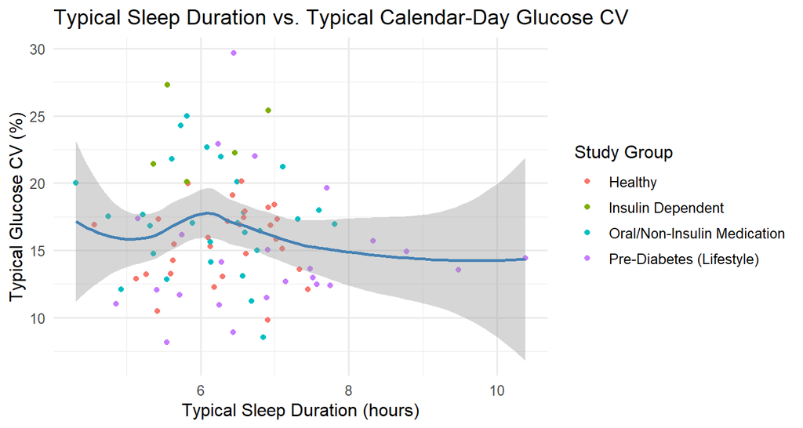

```r
group_labels <- c(
  "healthy" = "Healthy",
  "insulin_dependent" = "Insulin Dependent",
  "oral_medication_and_or_non_insulin_injectable_medication_controlled" = "Oral/Non-Insulin Medication",
  "pre_diabetes_lifestyle_controlled" = "Pre-Diabetes (Lifestyle)"
)

ggplot(participant_typical_summary,
       aes(x = typical_sleep_hours, y = typical_glucose_cv)) +
  geom_point(aes(color = study_group)) +
  geom_smooth(method = "loess", se = TRUE, color = "steelblue") +
  labs(
    title = "Typical Sleep Duration vs. Typical Calendar-Day Glucose CV",
    x = "Typical Sleep Duration (hours)",
    y = "Typical Glucose CV (%)",
    color = "Study Group"
  ) +
  scale_color_discrete(labels = group_labels) +
  scale_shape_discrete(labels = group_labels) +
  theme_minimal(base_size = 12)
```

The trend line depicted above is a **LOESS curve** (LOcally Estimated Scatterplot Smoothing), a flexible curved trend line that can bend to follow the local shape of the data.

The shaded gray area represents the **95% confidence band**. This confidence band is **narrower towards the middle** of the sleep-duration range, reflecting the larger concentration of participants there, allowing the model to have more data to estimate the trend confidently. Towards the extremes, where fewer participants are represented, the band widens considerably, indicating greater uncertainty in the estimated trend.

For the `insulin_dependent` study group, their typical glucose CV values tend to be **higher than the average** regardless of sleep duration, which is reasonable as that group struggles the most with diabetes control (requiring insulin to manage blood glucose)

### 6.3 Calculations for Scatterplot #1

```r
sleep_cv_cor <- cor.test(
  participant_typical_summary$typical_sleep_hours,
  participant_typical_summary$typical_glucose_cv,
  method = "spearman"
)
sleep_cv_cor
```

```
    Spearman's rank correlation rho

data:  participant_typical_summary$typical_sleep_hours and participant_typical_summary$typical_glucose_cv
S = 111645, p-value = 0.6259
alternative hypothesis: true rho is not equal to 0
sample estimates:
        rho
-0.05330566
```

```r
nrow(participant_typical_summary)
```

```
[1] 86
```

**Note**

**Number of Participants:** 86

Spearman Correlation indicates how strongly two variables move in the same direction (values being closer to +1 indicates strong positive correlation, closer to -1 indicates strong negative correlation).

P-value denotes the probability of a correlation this strong under the assumption that there was no relationship.

Together, a small spearman correlation combined with a large p-value suggests that there is no relationship in the scatterplot.

### 6.4 Scatterplot #2: Typical Daily Steps vs. Typical Calendar-Day Glucose CV

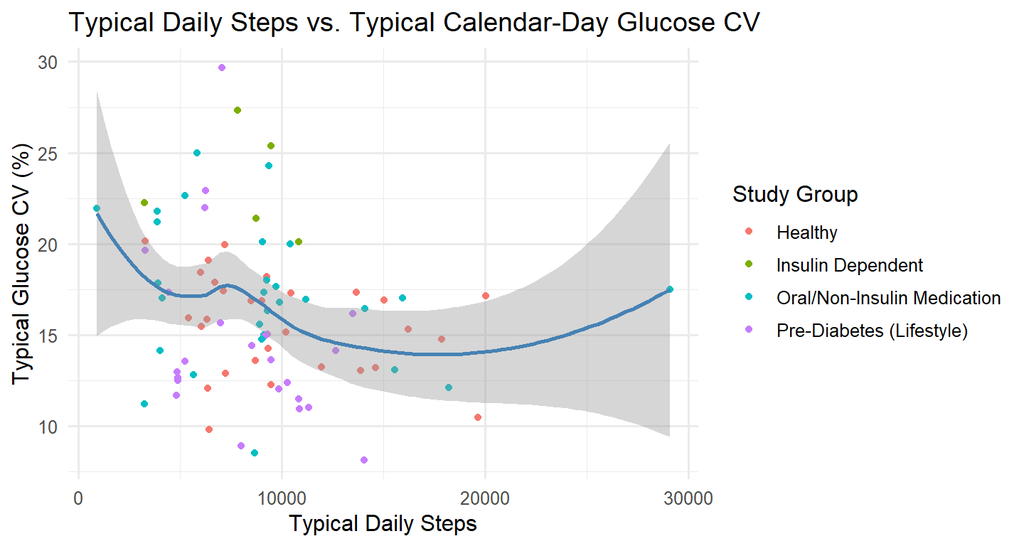

```r
group_labels <- c(
  "healthy" = "Healthy",
  "insulin_dependent" = "Insulin Dependent",
  "oral_medication_and_or_non_insulin_injectable_medication_controlled" = "Oral/Non-Insulin Medication",
  "pre_diabetes_lifestyle_controlled" = "Pre-Diabetes (Lifestyle)"
)

ggplot(participant_typical_summary,
       aes(x = typical_daily_steps, y = typical_glucose_cv)) +
  geom_point(aes(color = study_group)) +
  geom_smooth(method = "loess", se = TRUE, color = "steelblue") +
  labs(
    title = "Typical Daily Steps vs. Typical Calendar-Day Glucose CV",
    x = "Typical Daily Steps",
    y = "Typical Glucose CV (%)",
    color = "Study Group"
  ) +
  scale_color_discrete(labels = group_labels) +
  scale_shape_discrete(labels = group_labels) +
  theme_minimal(base_size = 12)
```

The trend line depicted above is a **LOESS curve** (LOcally Estimated Scatterplot Smoothing), a flexible curved trend line that can bend to follow the local shape of the data.

### 6.5 Calculations for Scatterplot #2

```r
sleep_cv_cor <- cor.test(
  participant_typical_summary$typical_daily_steps,
  participant_typical_summary$typical_glucose_cv,
  method = "spearman"
)

sleep_cv_cor
```

```
    Spearman's rank correlation rho

data:  participant_typical_summary$typical_daily_steps and participant_typical_summary$typical_glucose_cv
S = 132278, p-value = 0.02157
alternative hypothesis: true rho is not equal to 0
sample estimates:
       rho
-0.2479645
```

```r
nrow(participant_typical_summary)
```

```
[1] 86
```

**Note**

**Spearman Correlation:** -0.248

**P-Value:** 0.02157

**Number of Participants:** 86

Spearman Correlation indicates how strongly two variables move in the same direction (values being closer to +1 indicates strong positive correlation, closer to -1 indicates strong negative correlation).

P-value denotes the probability of a correlation this strong under the assumption that there was no relationship.

The spearman correlation appears to be weak-moderate negative, while the p-value is below the convention 0.05 threshold, meaning it can be considered statistically significant. Together, they could indicate that more daily steps could be associated with lower glucose CV, which might be biologically possible.

## 7 Conclusion